# Course Project

Ritesh Kumar Maurya

03/05/2020

Data source: http://web.archive.org/web/20161224072740/http:/groupware.les.inf.puc-rio.br/har

## Step1:

Loading required librares

```r
library(caret)
```

```r
library(ggplot2)
library(rlist)
library(e1071)
library(randomForest)
```

## Step:2

-> Loading training data set

```r
training = read.csv("E:/Practical Machine Learning/Prediction Assignment/pml-training.csv",
                    na.strings = c("","NA"))
#variable to store missing value columns
col <- NULL
#checking lissing value columns
for (i in 1:dim(training)[2])
  {
  if (sum(is.na(training[,i]))>0)
  {
   col <- c(col,i)
  }
}
#final training set
training <- training[,-col]
training <- training[,-c(1:7)]
dim(training)
```

```
## [1] 19622    53
```

We try to check correlations between variables.

These plots show us very little direct correlations between classe and predictor variables.

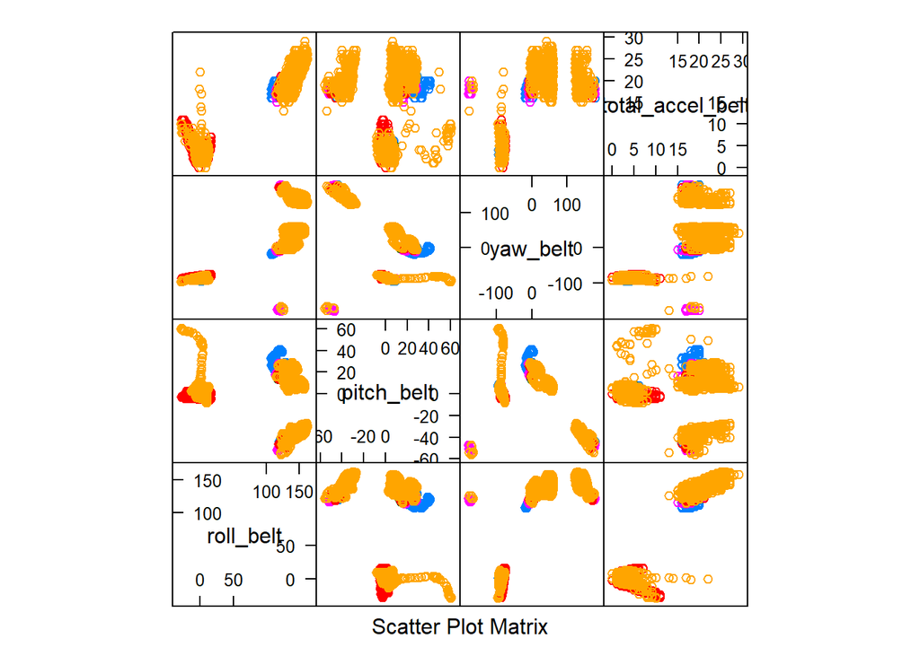

```r
featurePlot(training[,1:4], training[,53],"pairs" )
```

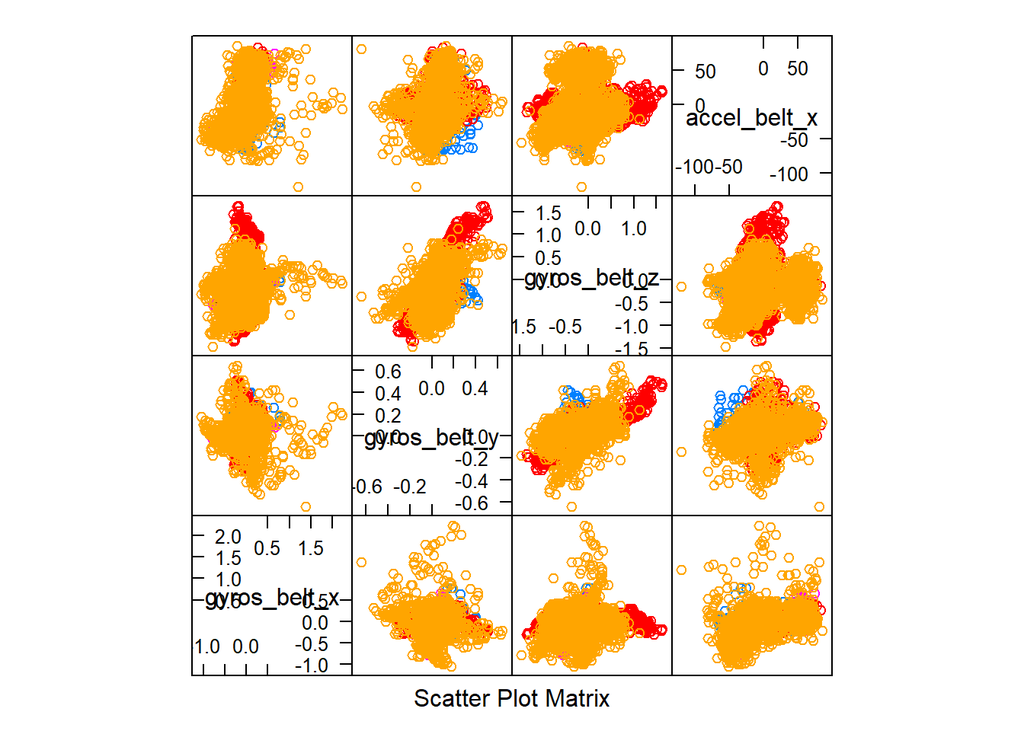

```r
featurePlot(training[,5:8], training[,53],"pairs" )
```

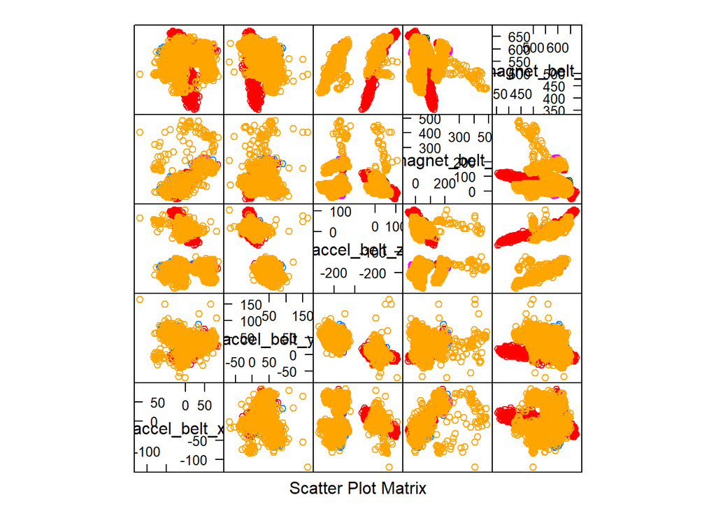

```r
featurePlot(training[,8:12], training[,53],"pairs" )
```

## Step:4

Training set is the only set we have got with classe information.

so we will split it into subsets of training and validation.

```r
inSubTrain = createDataPartition(y=training$classe,
                           p=0.6,
                           list=FALSE)
SubTrain = training[inSubTrain,]
SubTest = training[-inSubTrain,]

training <- SubTrain
validation <- SubTest
```

## Step:5

Since we could not find any very direct corelations so we will use all available variables and hope to go a good model.

Also, we will try to get accurate model with svm first then will try random forest.

Going through the paper on human activity recognition few researchers got very good accuracy by combining svm and naive bayes model

```r
mod1 <- svm(classe ~ .,
              data=training)
mod2 <- randomForest(classe ~ .,
              data= training,
              method="class")
```

## Step:6

Testing training set accuract and table on both the models

We observe randomForest is performing fantastic but this could also be because of overfitting

so we will test these models for validation set as well and check how they are performing

```r
PredTrainMod1 <- predict(mod1, training)
PredTrainMod2 <- predict(mod2, training, type="class")

print("SVM model on training")
```

```
## [1] "SVM model on training"
```

```r
confusionMatrix(PredTrainMod1, training$classe)$overall[1]
```

```
##  Accuracy
## 0.9526155
```

```r
table(PredTrainMod1, training$classe)
```

```
##
## PredTrainMod1    A    B    C    D    E
##             A 3342  138    0    2    0
##             B    2 2106   49    0    4
##             C    4   35 1974  180   57
##             D    0    0   27 1746   54
##             E    0    0    4    2 2050
```

```r
print("Random forest model on training")
```

```
## [1] "Random forest model on training"
```

```r
confusionMatrix(PredTrainMod2, training$classe)$overall[1]
```

```
## Accuracy
##        1
```

```r
table(PredTrainMod2, training$classe)
```

```
##
## PredTrainMod2    A    B    C    D    E
##             A 3348    0    0    0    0
##             B    0 2279    0    0    0
##             C    0    0 2054    0    0
##             D    0    0    0 1930    0
##             E    0    0    0    0 2165
```

In sample error [Random Forest]= 0

```r
PredValidationMod1 <- predict(mod1, validation)
PredValidationMod2 <- predict(mod2, validation, type="class")

print("SVM model on validation")
```

```
## [1] "SVM model on validation"
```

```r
confusionMatrix(PredValidationMod1, validation$classe)$overall[1]
```

```
##  Accuracy
## 0.9408616
```

```r
table(PredValidationMod1, validation$classe)
```

```
##
## PredValidationMod1    A    B    C    D    E
##                  A 2212  116    0    5    0
##                  B    4 1374   51    0   10
##                  C   13   28 1290  115   39
##                  D    0    0   25 1161   48
##                  E    3    0    2    5 1345
```

```r
print("Random forest model on validation")
```

```
## [1] "Random forest model on validation"
```

```r
confusionMatrix(PredValidationMod2, validation$classe)$overall[1]
```

```
##  Accuracy
## 0.9937548
```

```r
table(PredValidationMod2, validation$classe)
```

```
##
## PredValidationMod2    A    B    C    D    E
##                  A 2228   10    0    0    0
##                  B    4 1504   10    0    0
##                  C    0    4 1356   15    1
##                  D    0    0    2 1270    2
##                  E    0    0    0    1 1439
```

## This shows that random forest is still performing better than SVM.

So we will select random forest as final model.

## Step:7

Now we will apply same data treatment to testing set and run it on random forest model (mod2) to obtain our estimations on test data

```r
testing = read.csv("E:/Practical Machine Learning/Prediction Assignment/pml-testing.csv",
                   na.strings = c("","NA"))
col <- NULL

for (i in 1:dim(testing)[2])
{
  if (sum(is.na(testing[,i]))>0)
  {
    col <- c(col,i)
  }
}

testing <- testing[,-col]
testing <- testing[,-c(1:7)]
dim(testing)
```

```
## [1] 20 53
```

```r
PredTestMod2 <- predict(mod2, testing, type="class")
PredTestMod2
```

```
##  1  2  3  4  5  6  7  8  9 10 11 12 13 14 15 16 17 18 19 20
##  B  A  B  A  A  E  D  B  A  A  B  C  B  A  E  E  A  B  B  B
## Levels: A B C D E
```